# Instrumente Statistice pentru Finanțe

### 3.8.2 Funcția `pivot_wider()`

Funcția `pivot_wider()` are rolul opus funcției `pivot_longer()` și anume transformă un set de date într-un set de date lat (*wide*) prin creșterea numărului de coloane și scăderea numărului de linii. Se folosește în special atunci când mai multe variabile sunt stocate într-o singură coloană.

Să presupunem că avem următorul set de date

```r
gap_tab2
# A tibble: 16 x 4
   country      year type           count
   <chr>       <dbl> <chr>          <dbl>
 1 Afghanistan  1997 pop       22227415
 2 Afghanistan  1997 lifeExp         41.8
 3 Afghanistan  2007 pop       31889923
 4 Afghanistan  2007 lifeExp         43.8
 5 Brazil       1997 pop      168546719
 6 Brazil       1997 lifeExp         69.4
 7 Brazil       2007 pop      190010647
 8 Brazil       2007 lifeExp         72.4
 9 China        1997 pop     1230075000
10 China        1997 lifeExp         70.4
11 China        2007 pop     1318683096
12 China        2007 lifeExp         73.0
13 Romania      1997 pop       22562458
14 Romania      1997 lifeExp         69.7
15 Romania      2007 pop       22276056
16 Romania      2007 lifeExp         72.5
```

în care observăm că variabila `type` conține valorile a două variabile `pop` și respectiv `lifeExp`. Vom folosi funcția `pivot_wider()` pentru a aduce setul de date la formatul *tidy* dorit:

```r
gap_tab2 %>%
  pivot_wider(names_from = "type", values_from = "count") %>%
  head()
# A tibble: 6 x 4
  country      year        pop lifeExp
  <chr>       <dbl>      <dbl>   <dbl>
1 Afghanistan  1997   22227415    41.8
2 Afghanistan  2007   31889923    43.8
3 Brazil       1997  168546719    69.4
4 Brazil       2007  190010647    72.4
5 China        1997 1230075000    70.4
6 China        2007 1318683096    73.0
```

Funcția `pivot_woder()` primește următoarele argumente de bază:

-primul argument este setul de date

- al doilea argument este `names_from` care specifică numele variabilei din setul de date original care corespunde la numele variabilelor din setul de date transformat
- al treilea argument este `values_from` și specifică numele variabilei din setul de date original unde se regăsesc valorile corespunzătoare variabilelor din setul de date transformat

Pentru mai multe opțiuni și exemple de utilizare ale funcției `pivot_wider()` se poate consulta documentația `vignette("pivot")`.

## 3.9 Combinarea mai multor seturi de date

De cele mai multe ori analistul/statisticianul are de-a face cu mai multe seturi de date pentru a efectua analiza de interes și în această situație este important să dispună de instrumente care să-i permită să le combine într-un mod cât mai facil. În această secțiune vom prezenta o serie de funcții, disponibile în pachetul `dplyr`, care permit unirea a două seturi de date (`data.frame`) prin combinarea variabilelor din acestea. Interpretând că primul set de date este tabelul din stânga (`x`) iar cel de-al doilea, cel a cărui coloane vrem să le adăugăm primului, este cel din dreapta (`y`), avem mai multe posibilități de a le combina: `inner_join`, `left_join`, `right_join`, `full_join`, `anti_join` și `semi_join`. Pentru a ilustra cel șase tipuri de join vom considera următoarele două seturi de date (`df_x` în stânga și `df_y` în dreapta):

```r
df_x = gapminder %>%
  select(country, year, pop) %>%
  filter(year %in% 1975:1990,
         country %in% c("Romania", "Belgium"))

df_y = gapminder %>%
  select(country, year, continent, lifeExp) %>%
  filter(year %in% 1985:1998,
         country %in% c("Romania", "Belgium", "France"))
```

Avem:

1. `inner_join` - permite obținerea unui tabel a cărui linii sunt cele din `df_x` care au un corespondent în `df_y` și păstrează toate coloanele din `df_x` și `df_y`

```r
df_x %>%
  inner_join(df_y, by = "country")
# A tibble: 18 x 6
   country year.x      pop year.y continent lifeExp
   <chr>    <dbl>    <dbl>  <dbl> <chr>       <dbl>
 1 Belgium   1977  9821800   1987 Europe       75.4
 2 Belgium   1977  9821800   1992 Europe       76.5
 3 Belgium   1977  9821800   1997 Europe       77.5
 4 Belgium   1982  9856303   1987 Europe       75.4
 5 Belgium   1982  9856303   1992 Europe       76.5
 6 Belgium   1982  9856303   1997 Europe       77.5
 7 Belgium   1987  9870200   1987 Europe       75.4
 8 Belgium   1987  9870200   1992 Europe       76.5
 9 Belgium   1987  9870200   1997 Europe       77.5
10 Romania   1977 21658597   1987 Europe       69.5
11 Romania   1977 21658597   1992 Europe       69.4
12 Romania   1977 21658597   1997 Europe       69.7
13 Romania   1982 22356726   1987 Europe       69.5
14 Romania   1982 22356726   1992 Europe       69.4
15 Romania   1982 22356726   1997 Europe       69.7
16 Romania   1987 22686371   1987 Europe       69.5
17 Romania   1987 22686371   1992 Europe       69.4
18 Romania   1987 22686371   1997 Europe       69.7
```

În cazul în care variabila/variabilele de potrivire nu poartă același nume, atunci se poate specifica atributului `by` numele corespondenței `by = c("nume_x" = "nume_y")`.

2. `left_join` - permite obținerea unui tabel care va conține toate liniile din `df_x` și toate coloanele din `df_x` și `df_y` iar în cazul în care nu există un corespondent al liniilor primului tabel în cel de-al doilea va întoarce `NA`.

Funcția `right_join` se comportă în mod similar cu `left_join` inversând locurile seturilor de date.

3. `full_join` - permite obținerea unui tabel în care apar toate liniile și coloanele din ambele seturi de date iar pe pozițiite unde nu există corespondență între cele două se pune automat valoarea `NA`.
4. `anti_join` - permite obținerea unui tabel în care se regăsesc doar coloanele din primul set de date și doar acele linii ale acestuia care nu au corespondent în cel de-al doilea set de date
5. `semi_join` - permite obținerea unui tabel în care se regăsesc doar coloanele din primul set de date și doar acele linii ale acestuia care au corespondent în cel de-al doilea set de date

Pachetul `dplyr` pune la dispoziție și o serie de funcții care permit efectuarea de operații cu mulțimi. Aceste funcții primesc ca argumente două `data.frame`-uri care au acealeași coloane (aceleași variabile) și consideră observațiile ca elemente ale unei mulțimi:

- `intersect(df_x, df_y)` - întoarce un tabel doar cu observațiile comune din cele două seturi de date
- `union(df_x, df_y)` - întoarce un tabel cu observațiile unice din cele două seturi de date
- `setdiff(df_x, df_y)` - întoarce un tabel cu observațiile din primul set de date care nu se regăsesc în al doilea set de date

Pentru mai multe informații și exemple referitoare la modurile în care se pot combina două seturi de date se poate consulta (Wickham et al. 2019; Wickham and Grolemund 2017).

# 4 Vizualizarea datelor cu `ggplot2`

Tehnicile de vizualizarea a datelor joacă un rol important în orice analiză statistică, putând conduce la identificarea de noi caracteristici, perspective sau pattern-uri în acestea. Scopul acestei secțiuni este de a introduce o serie de elemente de vizualizare a datelor prin intermediul pachetului [ggplot2](https://ggplot2.tidyverse.org/). Pachetul a fost dezvoltat inițial de [Hadley Wickham](http://hadley.nz/) (care încă menține și îmbunătățește activ pachetul), este parte integrantă din suita [tidyverse](https://www.tidyverse.org/) și este bazat pe, ceea ce se numește în teoria vizualizării, *gramatica elemntelor grafice* introdusă de Leland Wilkinson în cartea [The Grammar of graphics](https://www.amazon.com/Grammar-Graphics-Statistics-Computing/dp/0387245448/ref=sr_1_fkmr0_1?ie=UTF8&qid=1493924426&sr=8-1-fkmr0&keywords=grammar+of+graphics+ggplot) (de aici vine și prefixul `gg` - grammar of graphics). Similar cu gramatica unei limbi, în care diferite elemente precum substantive, verbe, articole, prepoziții, etc. se pot combina după anumite reguli și *gramatica elementelor grafice* prezintă o serie de reguli care să permită construcția de grafice statistice prin combinarea mai multor tipuri de *straturi* (*layers*) (Wilkinson 2005). Astfel, ideea principală a pachetului `ggplot2` este de a specifica independent o serie de componente constructive ale graficului (obiecte geometrice), organizate în straturi, ce urmează a le combina pentru a genera figura dorită (Wickham 2016).

Ne dorim ca la finalul acestei secțiuni, să fim capabili să creăm grafice care să semene cu cele de mai jos:

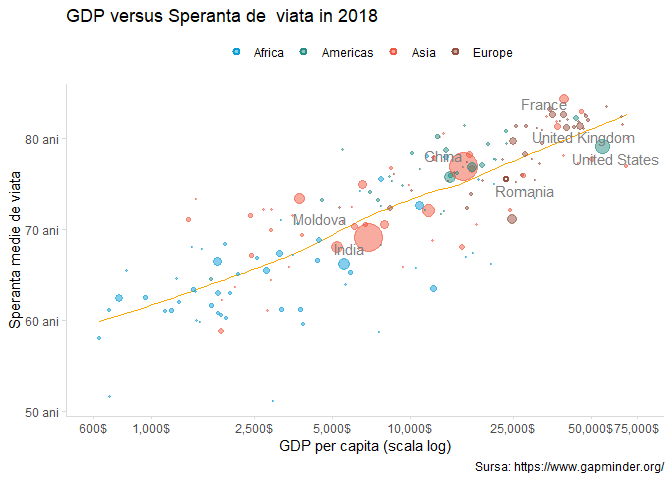

Exemplu de vizualizare realizata cu ajutorul pachetului ggplot2

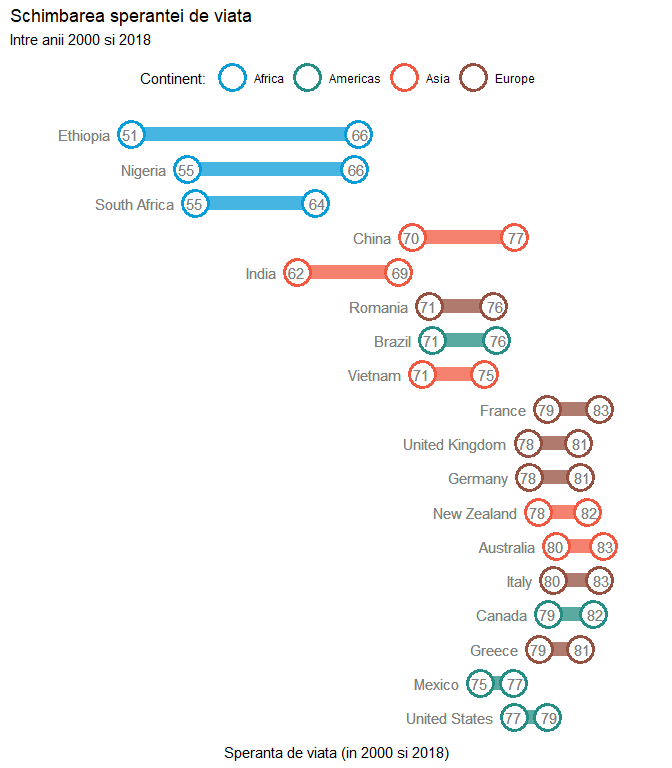

Exemplul 2 de vizualizare realizata cu ajutorul pachetului ggplot2

Înainte de prezentarea elementelor de bază ce compun un grafic folosind pachetul `ggplot2` și de a descrie fiecare componentă în parte, vom specifica care sunt datele (setul/seturile de date) pe care le vom utiliza pe parcursul acestui capitol.

## 4.1 Setul de date

Setul de date pe care îl vom folosi pentru a exemplifica elementele grafice introduse în acest capitol este creat prin manipularea unor date în format brut descărcate de pe platforma www.gapminder.org/data/. Mai precis vom descărca în format `csv` datele referitoare la durata medie de viață (sau speranța de viață) (*Health -> Life expectancy* sau http://gapm.io/ilex), produsul intern brut pe cap de locuitor ajustat la rata inflației (*Economy -> Incomes & growth -> Income* sau http://gapm.io/dgdppc) și respectiv populația totală (*Population -> Population* sau http://gapm.io/dpop) a peste 180 de state pe perioada 1800 - 2018. De asemenea, pentru a adăuga informații referitoare la locația geografică a țărilor din setul de date, respectiv continentul pe care se află fiecare țară, vom descărca fișierul [excel](http://gapm.io/datageo) de pe pagina https://www.gapminder.org/fw/four-regions/. Codul pentru crearea setului de date `gapminder_all` este ilustrat mai jos (acesta seamănă cu setul de date utilizat în capitolul de manipulare a datelor):

```r
# citim seturile de date
life_exp_gap = read_csv("dataIn/life_expectancy_years.csv")
tot_pop_gap = read_csv("dataIn/population_total.csv")
gdp_gap = read_csv("dataIn/income_per_person_gdppercapita_ppp_inflation_adjusted.csv")
countries_gap = read_excel("dataIn/Data Geographies - v1 - by Gapminder.xlsx", sheet = 2)

# transformam seturile de date
life_exp_gap_pivot = life_exp_gap %>%
  pivot_longer(cols = -country, names_to = "year", values_to = "lifeExp")

tot_pop_gap_pivot =tot_pop_gap %>%
  pivot_longer(cols = -country, names_to = "year", values_to = "pop")

gdp_gap_pivot = gdp_gap %>%
  pivot_longer(cols = -country, names_to = "year", values_to = "gdpPerCap")

countries_gap_keep = countries_gap %>%
  select(geo, name, four_regions,
         six_regions, "World bank region",
         "World bank, 4 income groups 2017") %>%
  rename(wb_region = "World bank region",
         wb_income = "World bank, 4 income groups 2017",
         country = "name")

# unim seturile de date
gapminder_all <- life_exp_gap_pivot %>%
  left_join(tot_pop_gap_pivot) %>%
  left_join(gdp_gap_pivot) %>%
  left_join(countries_gap_keep) %>%
  # capitalizarea primei litere, i.e. transformarea: asia -> Asia
  mutate(four_regions = str_to_title(four_regions))
```

Pentru a avea o imagine de ansamblu asupra setului de date construit vom folosi funcția `glimpse`:

```r
glimpse(gapminder_all)
Observations: 40,953
Variables: 10
$ country      <chr> "Afghanistan", "Afghanistan", "Afghanistan", "Afghanis...
$ year         <chr> "1800", "1801", "1802", "1803", "1804", "1805", "1806"...
$ lifeExp      <dbl> 28.2, 28.2, 28.2, 28.2, 28.2, 28.2, 28.1, 28.1, 28.1, ...
$ pop          <dbl> 3280000, 3280000, 3280000, 3280000, 3280000, 3280000, ...
$ gdpPerCap    <dbl> 603, 603, 603, 603, 603, 603, 603, 603, 603, 603, 604,...
$ geo          <chr> "afg", "afg", "afg", "afg", "afg", "afg", "afg", "afg"...
$ four_regions <chr> "Asia", "Asia", "Asia", "Asia", "Asia", "Asia", "Asia"...
$ six_regions  <chr> "south_asia", "south_asia", "south_asia", "south_asia"...
$ wb_region    <chr> "South Asia", "South Asia", "South Asia", "South Asia"...
$ wb_income    <chr> "Low income", "Low income", "Low income", "Low income"...
```

În multe din exemplele din această secțiune vom folosi doar datele corespunzătoare anului 2018 prin urmare vom crea și acest set de date și-l vom numi `gapminder_2018`:

```r
# setul de date pentru anul 2018
gapminder_2018 = gapminder_all%>%
  filter(year == 2018) %>%
  select(-geo) %>%
  rename(continent = four_regions)
```

Putem sumariza variabilele din setul de date `gapminder_2018` pentru a înțelege mai bine tipul lor și a avea mai multe informații referitoare la statisticile elementare (media, mediana, valoarea minimă și respectiv maximă, etc.) asociate acestora:

```r
summary(gapminder_2018)
   country              year              lifeExp           pop
 Length:187         Length:187         Min.   :51.10   Min.   :5.320e+04
 Class :character   Class :character   1st Qu.:67.10   1st Qu.:2.460e+06
 Mode  :character   Mode  :character   Median :74.05   Median :9.420e+06
                                       Mean   :72.66   Mean   :4.062e+07
                                       3rd Qu.:78.03   3rd Qu.:3.005e+07
                                       Max.   :84.20   Max.   :1.420e+09
                                       NA's   :3
   gdpPerCap       continent         six_regions         wb_region
 Min.   :   629   Length:187         Length:187         Length:187
 1st Qu.:  3605   Class :character   Class :character   Class :character
 Median : 11700   Mode  :character   Mode  :character   Mode  :character
 Mean   : 17984
 3rd Qu.: 25200
 Max.   :121000

  wb_income
 Length:187
 Class :character
 Mode  :character
```

Observăm că pentru variabila `lifeExp` avem trei observații care nu prezintă valori, prin urmare putem exclude acele observații din setul de date:

```r
gapminder_2018 = gapminder_2018 %>%
  filter(!is.na(lifeExp))
```

## 4.2 Elemente de bază

Graficele (figurile) realizate prin intermediul pachetului `ggplot2` au la bază o serie de elementele constructive, printe care putem enumera:

- setul de date ce urmează să fie prezentat grafic (**data**) - acesta *trebuie* să fie sub forma unui `data.frame` (adus la un format *tidy*)
- obiectele geometrice (**geom**) ce urmează să apară pe grafic (puncte, linii, etc.)
- o serie de corespondențe (**mappings**) de la variabilele din setul de date la aspectul (estetica - **aesthetics**) obiectelor geometrice
- transformări statistice (**statistical transformations**) folosite pentru a calcula valorile datelor ce sunt utilizate în grafic
- ajustări ale pozițiilor (**position adjustments**) obiectelor geometrice pe grafic
- scalări și scale (**scales**) pentru fiecare corespondență estetică folosită
- sisteme de coordonate (**coordinate systems**)
- fațete (**facets**) sau grupuri de date folosite în figuri diferite

Aceste componente constructive ale unui grafic sunt organizate în straturi (*layers*), unde fiecare strat conține un singur obiect grafic, transformare statistică sau ajustare de poziție și astfel putem vizualiza o figură/un grafic ca pe o mulțime de straturi de imagini suprapuse, fiecare prezentând un anumit aspect al datelor.

[output not shown]

Primul pas în crearea unui grafic folosind pachetul `ggplot2` este de a construi un obiect *ggplot*. Acest obiect, creat prin intermediul funcției `ggplot()`, inițializează suprafața de desen (*canvas*) fără a desena nimic pe ea. Prin apelarea acestei funcții se specifică, în general, atât setul de date (în format `data.frame`) care va fi folosit în ilustrația grafică precum și proprietățile estetice (ce țin de aspect) care vor fi aplicate (vor corespunde) obiectelor geometrice folosite ulterior. Cu alte cuvinte, vom spune funcției `ggplot` care sunt datele pe care urmărim să le ilustrăm grafic și cum fiecare varaibilă din acest set de date va fi folosită (e.g. ca și coordonate x, y sau ca variabile de colorare - *colour* ori mărime - *size*, etc.). Este important de specificat că setul de date **trebuie** să fie sub forma unui `data.frame` adus la un format *tidy*. Codul generic este:

```r
# il atribuim unui obiect
obiect = ggplot(data = <DATAFRAME>, aes(x = <COLOANA_1>, y = <COLOANA_2>))

# nu il atribuim unui obiect
ggplot(data = <DATAFRAME>, aes(x = <COLOANA_1>, y = <COLOANA_2>))
```

Sumarizând avem următorii pași ilustrați în figura de mai jos:

1. Apelăm funcția `ggplot()` care ne va crea o suprafață de desen goală
2. Specificăm corespondențele estetice (*aesthetic mappings*) dintre variabiele setului de date și elemente ce țin de aspect. În acest caz, pentru setul de date `gapminder_2018`, între variabilele `gdpPerCap` și `lifeExp` și axele x și y.
3. Adăugăm obiecte geometrice care vor apărea pe grafic. În cazul nostru vom folosi stratul `geom_point()` pentru a adăuga puncte ca elemente grafice care să reprezinte datele.

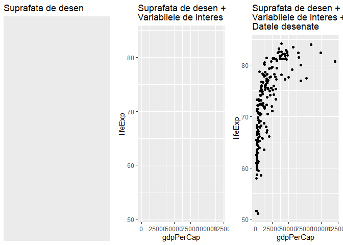

```r
# crearea suprafetei de desenare
ggplot(gapminder_2018)

# variabilele de interes sunt afisate
ggplot(gapminder_2018, aes(x = gdpPerCap, y = lifeExp))

# datele desenate
ggplot(gapminder_2018, aes(x = gdpPerCap, y = lifeExp)) +
  geom_point()
```

Este de remarcat faptul că atunci când am folosit stratul *geom* am utilizat operatorul `+`. De fiecare dată când vom adăuga un nou strat grafic la figura noastră o vom face prin intermediul operatorului `+`. Funcția `geom_point()` este doar o scriere prescurtată de trasare a graficului, în realitate se apelează funcția `layer()` care în fapt construiește un nou strat în care se specifică una din cele cinci componente principale `mapping`, `data`, `geom`, `stat` și `position`:

```r
ggplot(gapminder_2018, aes(x = gdpPerCap, y = lifeExp)) +
  layer(
    mapping = NULL,
    data = NULL,
    geom = "point",
    stat = "identity",
    position = "identity"
    )
```

Structura generică a unui grafic realizat în `ggplot2` este:

```r
ggplot(data = [DATA]) +         # element obligatoriu
 [GEOM_FUNCTION](
    mapping = aes([MAPPINGS]),  # element obligatoriu
    stat = [STAT],              # element optional
    position = [POSITION]       # element optional
  ) +
 [COORDINATE_FUNCTION] +        # element optional
 [FACET_FUNCTION] +             # element optional
 [SCALE_FUNCTION] +             # element optional
 [THEME_FUNCTION]               # element optional
```

## 4.3 Corespondențe estetice (*aesthetic mappings*)

Corespondențele estetice, de aspect, (aesthetic mappings) preiau proprietăți ale datelor și le folosesc pentru a influența o serie de caracteristici vizuale ale figurii, precum poziția, culoarea, mărimea, forma sau transparența. Astfel fiecare caracteristică vizuală poate codifica un aspect al datelor și, prin urmare, poate fi utilizată pentru a transmite noi informații. Toate elementele estetice se specifică folosind funcția `aes()` atât în interiorul funcției `ggplot` unde dobândesc un caracter global cât și în interiorul fiecărui strat definit de un obiect geometric (*geom*). De exemplu, în figura de mai jos, pentru setul de date `gapminder_2018`, culoarea (definită prin estetica `colour =`) descrie (corespunde la) apartenența la continent, poziția x arată produsul intern brut al statelor (`gdpPerCap`) iar poziția y arată speranța medie de viață (`lifeExp`).

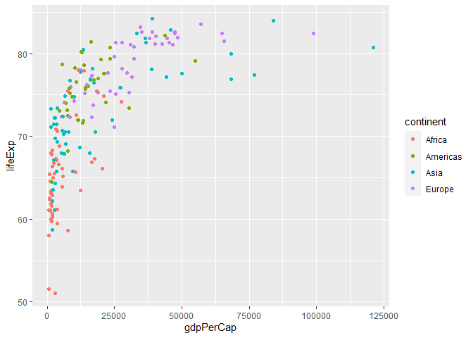

```r
# caracter global pentru colour
ggplot(gapminder_2018, aes(x = gdpPerCap, y = lifeExp, colour = continent)) +
  geom_point()

# sau local
ggplot(gapminder_2018, aes(x = gdpPerCap, y = lifeExp)) +
  geom_point(aes(colour = continent))
```

Diferența dintre caracterul global și cel local al elementelor estetice (atunci când sunt aplicate funcției `ggplot` sau a straturilor individuale) se poate observa în figura de mai jos, unde adăugăm la grafic dreptele de regresie corespunzătoare țărilor de pe fiecare continent. Astfel, în cazul global, dreptele de regresie sunt asociate pentru fiecare subset de date (determinate de variabila `continent` prin intermediul esteticii de culoare) pe când atunci când elementul estetic este specificat în cadrul stratului geometric local (`geom_point()`)) se asociază dreapta de regresie asociată întregului set de date.

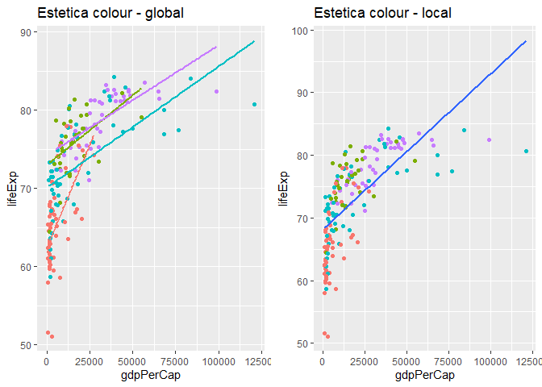

```r
# global
ggplot(gapminder_2018, aes(x = gdpPerCap, y = lifeExp, colour = continent)) +
  geom_point() +
  geom_smooth(method = "lm", se = FALSE)

# local
ggplot(gapminder_2018, aes(x = gdpPerCap, y = lifeExp)) +
  geom_point(aes(colour = continent)) +
  geom_smooth(method = "lm", se = FALSE)
```

Elementele estetice ce pot fi utilizate pentru trasarea unei figuri depind de tipul de obiect/strat geometric (*geom*) folosit. Pentru mai multe informații se poate consulta documentația funcțiilor `geom` la secțiunea *Aesthetics* (e.g. `?geom.point`) unde elementele obligatorii apar îngroșate iar cele opționale apar normal.

Printre cele mai uzuale elemente estitice ale unui grafic enumerăm:

| Element estetic (aesthetic) | Descriere |
| --- | --- |
| `x` | Poziția pe axa absciselor (x-axis) |
| `y` | Poziția pe axa ordonatelor (y-axis) |
| `shape` | Forma punctelor |
| `color`/`colour` | Culoarea marginală a elementelor |
| `fill` | Culoarea de umplere, interioară, a elementelor |
| `size` | Mărimea |
| `alpha` | Tranparență (1 - opac, 0 - transparent) |
| `linetype` | Tipul liniei (e.g. solidă, punctată, etc.) |

O prezentare generală și mai amănunțită a acestora se regăsește în vigneta pachetului `ggplot2` intitulată `Aesthetic specifications` care poate fi apelată prin

```r
vignette("ggplot2-specs")
```

Trebuie remarcat faptul că prin utilizarea funcției `aes()`, canalul vizual va fi determinat să se bazeze pe datele specificate în argument. De exemplu, atunci când folosim comanda `aes(colour = "blue")` nu va face ca obiectul geometric (în cazul de mai sus punctele) să aibă culoarea albastră, ci va face maparea ca și cum am avea un singur tip numit “albastru”. În cazul în care dorim să aplicăm valoarea elementului estetic întregului obiect geometric, de exemplu să schimbăm culoarea punctelor în albastru, atunci trebuie să specificăm elementul estetic în afara funcției `aes()`:

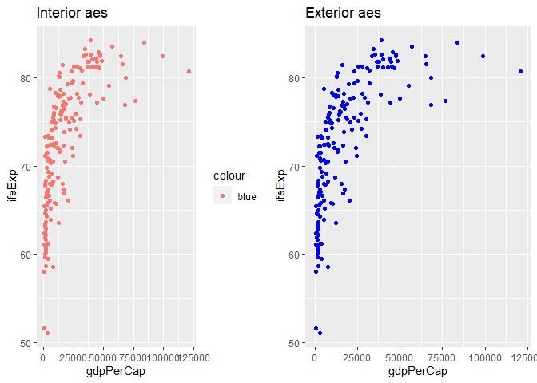

```r
# interior
ggplot(gapminder_2018, aes(x = gdpPerCap, y = lifeExp)) +
  geom_point(aes(colour = "blue"))
# exterior
ggplot(gapminder_2018, aes(x = gdpPerCap, y = lifeExp)) +
  geom_point(colour = "blue")
```

Putem face acest lucru pentru fiecare caracteristică estetică, incluzând `colour`, `fill`, `shape` sau `size`. În exemplul de mai jos schimbăm culoarea, mărimea și forma punctelor:

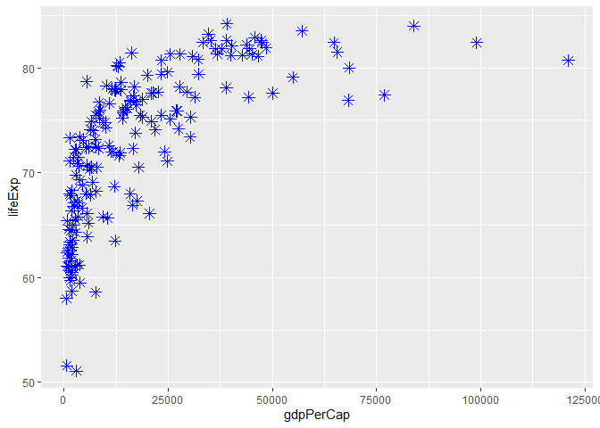

```r
ggplot(gapminder_2018, aes(x = gdpPerCap, y = lifeExp)) +
  geom_point(colour = "blue", size = 3, shape = 8)
```

Atribuirea unei valori fixate (unei constante) unei estetici în interiorul funcției `aes()` poate fi utilă în special atunci când dorim să ilustrăm mai multe straturi cu diverși parametrii și în care dorim să numim acești parametrii. Spre exemplu să presupunem că dorim să ajustăm mai multe modele de regresie la setul de date `gapminder_2018` și să scoatem în evidență curbele generate.

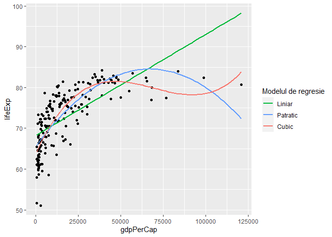

```r
ggplot(gapminder_2018, aes(x = gdpPerCap, y = lifeExp)) +
  geom_point() +
  geom_smooth(method = "lm",
              se = FALSE,
              aes(color = "Liniar") ) +
  geom_smooth(method = "lm",
              formula = y ~ poly(x, 2),
              se = FALSE,
              aes(color = "Patratic") ) +
  geom_smooth(method = "lm",
              formula = y ~ poly(x, 3),
              se = FALSE,
              aes(color = "Cubic") )
```

## 4.4 Obiecte geometrice (*geometric objects*)

Obiectele geometrice (*geometric objects*), sau `geom` pe scurt, sunt elementele fundamentale ale unui grafic creat în `ggplot2`, prin intermediul lor se efectuează reprezentarea a datelor, controlând tipul de grafic dorit. Neincluderea unui strat `geom` în desen conduce la o figură goală (a se vedea mai sus). Majoritatea obiectelor geometrice sunt asociate unui grafic a cărui denumire este prestabilită, astfel `geom_bar` corespunde unei diagrame cu bare (*barplot*), `geom_line` corespunde unei diagrame liniare (*linegraph*), `geom_histogram` corespunde unei histograme, `geom_boxplot` corespunde unei diagrame de tip boxplot (*cutie cu mustăți*) ș.a.m.d. O excepție de la această regulă este dată de diagrama de împrăștiere (*scatterplot*) pentru care se folosește `geom_point`.

Fiecare funcție `geom` are propriile elemente estetice și argumente necesare pentru a ajusta modul în care este creat graficul. De exemplu, funcția `geom_histogram` necesită doar elementul estetic `x` pe când dacă dorim să trasăm o diagramă de împrăștiere avem nevoie atât de estetica `x` cât și de `y`. În contextul setului de date `gapminder_2018`, variabila `gdpPerCap` ne arată produsul intern brut pe cap de locuitor pentru fiecare țară iar variabila `lifeExp` prezintă speranța medie de viață din țara respectivă. Pentru a vedea cum este distribuit produsul intern brut pentru anul 2018 vom trasa o histogramă a acestuia iar pentru a investiga relația dintre variabilele `gdpPerCap` și `lifeExp` vom ilustra o diagramă de împrăștiere:

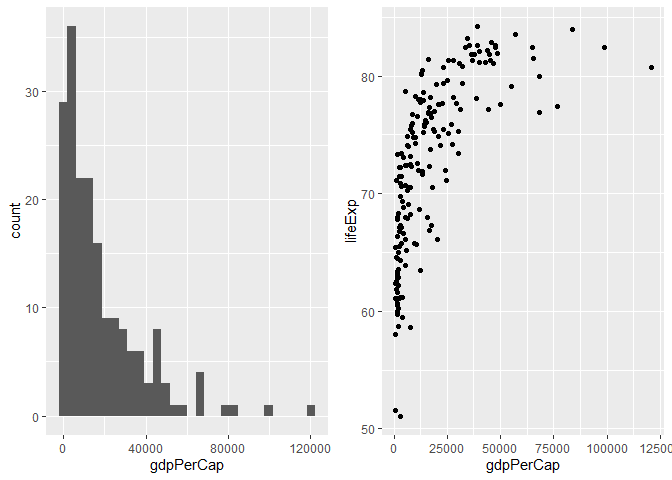

```r
# histograma
ggplot(gapminder_2018, aes(x = gdpPerCap)) +
  geom_histogram()

# diagrama de imprastiere - scatterplot
ggplot(gapminder_2018, aes(x = gdpPerCap, y = lifeExp)) +
  geom_point()
```

Pentru fiecare funcție `geom` există elemente estetice obligatorii și opționale. Majoritatea obiectelor grafice necesită elementele estetice `x` și `y` dar sunt și excepții precum `geom_bar` sau `geom_histogram`. De exemplu, în cazul funcției `geom_point`, elementele estetice obligatorii sunt `x` și `y` iar cele opționale pot include: `alpha` (transparență), `colour`, `fill`, `size`, `shape` sau `stroke`. Trebuie menționat că elementele estetice pot să difere de la `geom` la `geom` în funcție de specificul vizual al fiecărui obiect grafic, de exemplu putem utiliza `shape` ca estetică pentru `geom_point` dar nu o putem utiliza și pentru `geom_line` precum putem utiliza `linetype` pentru `geom_line` dar nu și pentru `geom_point`.

În contextul setului de date `gapminder_2018` vom utiliza atât estetica `colour` pentru a diferenția tările în funcție de `continent` cât și estetica `size` pentru a scoate în evidență tările cu o populație (`pop`) mai mare:

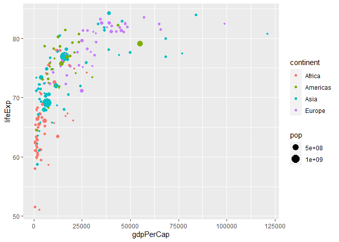

```r
ggplot(gapminder_2018, aes(x = gdpPerCap, y = lifeExp, colour = continent, size = pop)) +
  geom_point()
```

Pe lângă elementele estetice, funcțiile `geom` admit și o serie de argumente specifice (care se regăsesc la secțiunea *arguments* în documentația acestora, e.g. `?geom_point`), de exemplu dacă dorim să modificăm numărul de subintervale (*bins*) folosit pentru trasarea unei histograme atunci putem utiliza argumentul `bins =`:

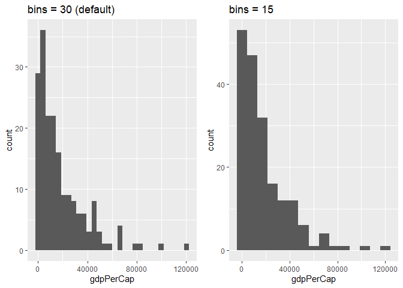

```r
# histograma
ggplot(gapminder_2018, aes(x = gdpPerCap)) +
  geom_histogram(bins = 15)
```

Următorul tabel prezintă o serie de funcții `geom` împreună cu elementele estetice obligatorii și o parte din argumentele specifice ale acestora.

| Funcția | Elemente estetice | Argumente opționale | Descriere |
| --- | --- | --- | --- |
| `geom_point` | x, y |  | Trasează o diagramă de împrăștiere |
| `geom_line` | x, y | arrow, na.rm | Trasează o diagramă liniară |
| `geom_segment` | x, y, xend, yend | arrow, na.rm | Trasează un segment de dreaptă |
| `geom_path` | x, y | na.rm | Trasează o linie poligonală |
| `geom_polygon` | x, y |  | Trasează o linie poligonală închisă (umplută) |
| `geom_rect` | xmin, xmax, ymin, ymaxl |  | Trasează un dreptunghi |
| `geom_histogram` | x | bins, binwidth | Trasează o histogramă |
| `geom_density` | x |  | Trasează o diagramă de densitate estimată prin nuclee |
| `geom_dotplot` | x | bins, binwidth | Trasează o diagramă cu puncte similară diagramei cu bare |
| `geom_freqpoly` | x | binwidth | Trasează o linie poligonală de frecvență |
| `geom_bar` | x sau x, y | width | Trasează o diagramă cu bare |
| `geom_abline` | intercept, slope |  | Trasează drepte în care sunt specificate pantele și ordonatele la origine |
| `geom_hline` | yintercept |  | Trasează drepte de referință orizontale |
| `geom_vline` | xintercept |  | Trasează drepte de referință verticale |
| `geom_smooth` | x, y | method, se, span | Adaugă o curbă de regresie |
| `geom_text` | x, y, label |  | Adaugă etichete text la puncte |
| `geom_bin2d` | x, y | bins | Ilustrează o estimare a densității bivariate prin dreptunghiuri |
| `geom_hex` | x, y | bins | Ilustrează o estimare a densității bivariate prin hexagoane (faguri) |

Vom prezenta mai jos o parte dintre graficele generate de aceste funcții în contextul seturilor de date `gapminder_all` și `gapminder_2018`. Vom face separarea graficelor după numărul (una sau două) și tipul (discrete sau continue) variabilelor analizate:

- o variabilă discretă - `geom_bar()`

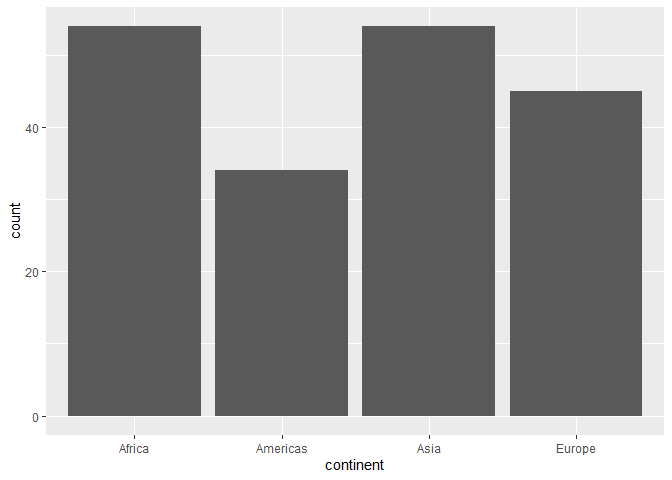

```r
ggplot(gapminder_2018, aes(x = continent)) +
  geom_bar()
```

- o variabilă continuă - `geom_histogram`, `geom_density`, `geom_dotplot` și `geom_freqpoly`

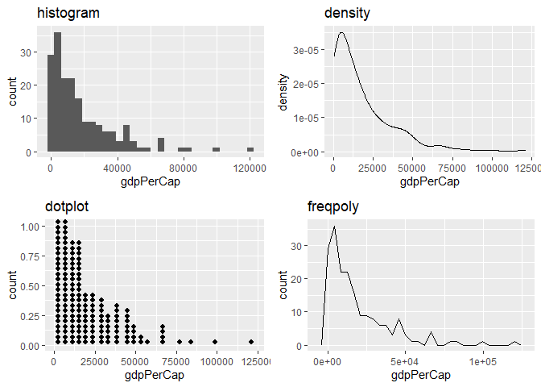

```r
# histograma
ggplot(gapminder_2018, aes(x = gdpPerCap)) +
  geom_histogram()

# estimarea densitatii
ggplot(gapminder_2018, aes(x = gdpPerCap)) +
  geom_density()

# dotplot
ggplot(gapminder_2018, aes(x = gdpPerCap)) +
  geom_dotplot()

# diagrama de frecvente
ggplot(gapminder_2018, aes(x = gdpPerCap)) +
  geom_freqpoly()
```

- două variabile ambele continue - `geom_point`, `geom_line`, `geom_smooth`, `geom_bin2d`, `geom_hex`, etc.

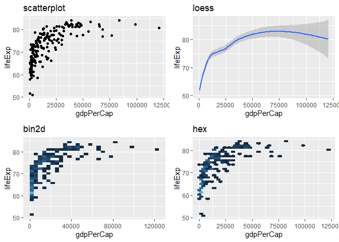

```r
# Diagrama de imprastiere
ggplot(gapminder_2018, aes(x = gdpPerCap, y = lifeExp)) +
  geom_point()

# Functia de regresie - default loess
ggplot(gapminder_2018, aes(x = gdpPerCap, y = lifeExp)) +
  geom_smooth()

# Densitate bivariata
ggplot(gapminder_2018, aes(x = gdpPerCap, y = lifeExp)) +
  geom_bind2d()

# Densitate bivariata
ggplot(gapminder_2018, aes(x = gdpPerCap, y = lifeExp)) +
  geom_hex()
```

- o variabilă continuă și una discretă - `geom_bar(stat = "identity")` (sau `geom_col`), `geom_boxplot`, `geom_violin`, etc.

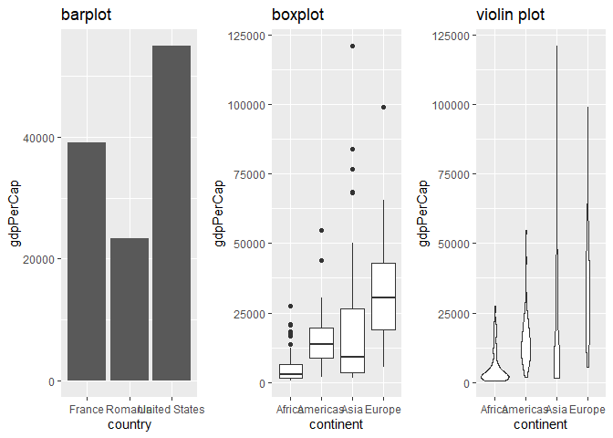

```r
# datele
gap1 = gapminder_2018 %>%
  filter(country %in% c("Romania", "United States", "France"))

# barplot
ggplot(gap1, aes(x = country, y = gdpPerCap)) +
  geom_bar(stat = "identity")
# sau
ggplot(gap1, aes(x = country, y = gdpPerCap)) +
  geom_col()

# boxplot
ggplot(gapminder_2018, aes(x = continent, y = gdpPerCap)) +
  geom_boxplot()
```

- o variabilă continuă și alta de tip temporal: `geom_line`, `geom_area`

[figure not shown]

```r
# diagrama liniara
ggplot(gapminder_all %>% filter(country == "Romania"),
       aes(x = as.numeric(year), y = gdpPerCap)) +
  geom_line()

# area plot
ggplot(gapminder_all %>% filter(country == "Romania"),
       aes(x = as.numeric(year), y = gdpPerCap)) +
  geom_line()
```

Ceea ce face pachetul `ggplot2` cu adevărat puternic este că acesta permite construcția de figuri complexe prin adăugarea mai multor obiecte grafice la aceeași figură, suprapunând straturile determinate de ele. Să considerăm setul de date `gapminder_2018` și să adăugăm la diagrama de împrăștiere a variabilelor `gdpPerCap` și `lifeExp` relația liniară determinată de dreapta de regresie:

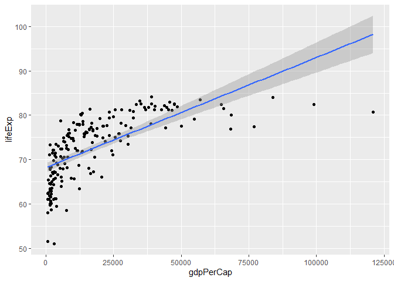

```r
ggplot(gapminder_2018, aes(x = gdpPerCap, y = lifeExp)) +
  geom_point() +
  geom_smooth(method = "lm")
```

Trebuie remarcat faptul că putem utiliza elemente estetice diferite pentru fiecare obiect geometric folosit, de exemplu în figura anterioară putem schimba culoarea punctelor și a dreptei de regresie.

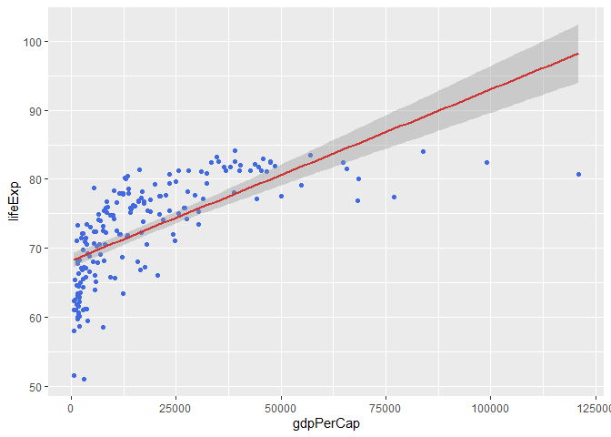

```r
ggplot(gapminder_2018, aes(x = gdpPerCap, y = lifeExp)) +
  geom_point(color = "royalblue") +
  geom_smooth(method = "lm", color = "brown3")
```

De asemenea, este posibil să atribuim fiecărui strat `geom` propriul set de date astfel încât să putem utiliza mai multe seturi de date pentru a scoate în evidență caracteristicile de interes ale graficului (variabilelor). În contextul diagramei de împrăștiere dintre produsul intern brut pe cap de locuitor și speranța medie de viață pentru setul de date `gapminder_2018` vrem să adăugăm numele (etichetele - label) țărilor care au mai mult de 200 milioane de locuitori și să colorăm punctele în roșu. Pentru început, vom construi setul de date cu țările corespunzătoare și apoi vom adăuga informația folosind `geom_text`. Etichetarea elementelor grafice se poate face cu `geom_text` sau `geom_label` dar atunci când punctele sunt foarte aglomerate se pot folosi și funcții alternative precum cele din pachetul `ggrepel` (`geom_text_repel` sau `geom_label_repel`). Pentru a colora punctele vom folosi estetica `colour` într-un nou strat `geom_point`. :

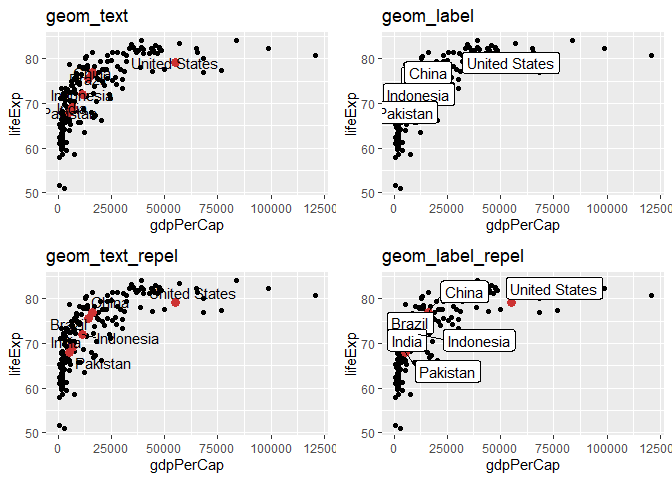

```r
tari_mari = gapminder_2018 %>%
  filter(pop > 2e8)

ggplot(gapminder_2018, aes(x = gdpPerCap, y = lifeExp)) +
  geom_point() +
  geom_point(data = tari_mari,
             aes(x = gdpPerCap, y = lifeExp),
             colour = "brown3", size = 3) +
  geom_text(data = tari_mari, aes(label = country))
```

Sunt și situații în care dorim să separăm datele în grupuri dar vrem să le redăm în același mod, de exemplu atunci când avem un studiu longitudinal (studiu care presupune observații repetate asupra acelorași variabile) cu mai mulți subiecți. Acest tip de situație, întâlnit în cazul în care un `geom` afișează observații multiple printr-un singur obiect geometric (e.g. `geom_boxplot`), necesită separarea pe grupe a observațiilor, fapt realizat prin intermediul elementului estetic `group`. Pentru o mai bună înțelegere vom ilustra acest concept folosind setul de date `gapminder_all`. Să presupunem că dorim să afișăm evoluția duratei medii de viață după anul 1900 pentru o submulțime de țări (*Romania*, *Moldova* și *France*).

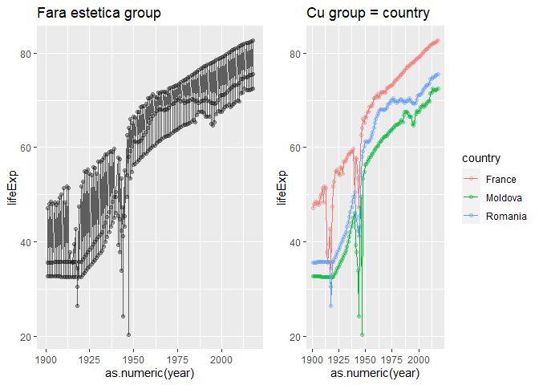

```r
gapminder_all %>%
  filter(as.numeric(year) > 1900) %>%
  filter(country %in% c("Romania", "Moldova", "France")) %>%
ggplot(aes(x = year, y = lifeExp)) +
  geom_point()+
  geom_line()

gapminder_all %>%
  filter(as.numeric(year) > 1900) %>%
  filter(country %in% c("Romania", "Moldova", "France")) %>%
ggplot(aes(x = year, y = lifeExp, group = country, colour = country)) +
  geom_point()+
  geom_line()
```

## 4.5 Transformări statistice (*statistical transformations*)

Pachetul `ggplot2` folosește o serie de transformări statistice, sau `stat`, pentru a aduce datele la formatul dorit pentru trasare. Forma generală a acestora este `stat_[nume statistică]`. De obicei aceste transformări sumarizează datele într-un anume fel, de exemplu în cazul unui *boxplot* pentru valorile de pe `y` se caculează mediana ($Q_2$), prima și a treia cuartila ($Q_1$ și $Q_3$) și distanța dintre acestea ($IQR$), iar în cazul unei curbe de regresie (`geom_smooth`) se calculează valoarea medie a lui `y` condiționată la `x`. Un alt exemplu constă în trasarea unei diagrame cu bare (*barplot*) în care axa `y` este definită ca fiind numărul de elemente din fiecare clasă (`count`) a lui `x`, număr care nu aparține setului de date inițial ci este obținut prin aplicarea unei transformări statitice `stat_count`. Fiecare obiect geometric `geom` admite o transformare statistică predefinită și vice versa dar acestea pot fi schimbate. De exemplu, transformarea statistică predefinită pentru `geom_bar` este `stat_count`

```r
# argumentele functiei geom_bar
args(geom_bar)
function (mapping = NULL, data = NULL, stat = "count", position = "stack",
    ..., width = NULL, binwidth = NULL, na.rm = FALSE, orientation = NA,
    show.legend = NA, inherit.aes = TRUE)
NULL

# argumentele functiei stat_count
args(stat_count)
function (mapping = NULL, data = NULL, geom = "bar", position = "stack",
    ..., width = NULL, na.rm = FALSE, orientation = NA, show.legend = NA,
    inherit.aes = TRUE)
NULL
```

Următorul tabel prezintă o serie de transformări statistice și obiectele geometrice pentru care acestea reprezintă un comportament implicit:

| Transformare statistică | Obiect geometric |
| --- | --- |
| `stat_identity` | `geom_point` |
| `stat_count()` | `geom_bar()` |
| `stat_bin()` | `geom_freqpoly()`, `geom_histogram()` |
| `stat_boxplot()` | `geom_boxplot()` |
| `stat_smooth()` | `geom_smooth()` |
| `stat_bin2d()` | `geom_bin2d()` |
| `stat_binhex()` | `geom_hex()` |
| `stat_bindot()` | `geom_dotplot()` |
| `stat_contour()` | `geom_contour()` |

De exemplu transformarea *identitate* (*identity*) va lăsa datele așa cum sunt și folosită în `geom_bar` conduce la construcția unei diagrame cu bare în care pe axa `y` se află valorile variabilei `y` fără a mai efectua transformarea (în acest caz este nevoie atât de estetica `x` cât și de `y`). În figura următoare afișăm populația totală a țărilor de pe fiecare dintre cele patru continente considerate în setul de date `gapminder_2018`:

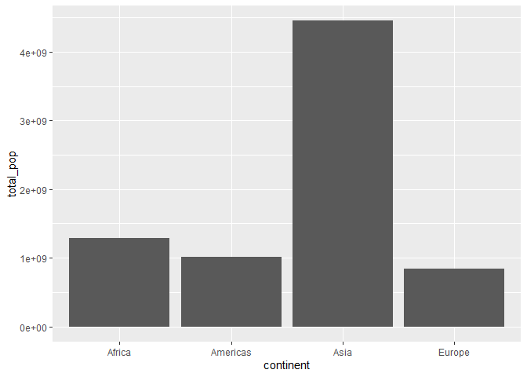

```r
gapminder_2018 %>%
  group_by(continent) %>%
  summarise(n = n(),
            max_pop = max(pop),
            total_pop = sum(pop)) %>%
  ggplot(aes(x = continent, y = total_pop)) +
  geom_bar(stat = "identity")
```

Pe lângă transformările implicite există și o serie de transformări care nu pot fi create prin aplicarea funcțiilor `geom_`. Tabelul de mai jos prezintă o parte dintre acestea (pentru mai multe informații se poate consulta documentația pachetului `ggplot2` la adresa https://ggplot2.tidyverse.org/reference/index.html#section-layer-stats):

| Transformare statistică | Descriere |
| --- | --- |
| `stat_ecdf()` | calculează și ilustrează funcția de repartiție empirică |
| `stat_function()` | calculează valorile lui y aplicând o funcție valorilor lui x |
| `stat_summary()` | sumarizează valorile lui y la clase diferite în x |
| `stat_summary2d()`, `stat_summary_hex()` | este o versiune bidimensională a lui `stat_summary` |
| `stat_unique()` | elimină valorile duplicate |
| `stat_qq()` | efectuează calculele pentru un grafic cuantilă-cuantilă |

Pentru a folosi aceste funcții putem sau să le apelăm în mod direct utilizând `stat_[nume]` și astfel suprascriind obiectul geometric sau să le apelăm în interiorul unui strat geometric. Pentru ilustrare vom folosi setul de date `gapminder_all` în care vom trasa o diagramă de împrăștiere unde pe axa x avem anii de după 1900 iar pe y speranța medie de viață a țărilor europene (pentru a evita supraaglomerarea punctelor - *ovreplotting* vom folosi estetic `alpha = 0.1`). Vom adăuga cu roșu la acestă diagramă valoarea mediană a duratei medii de viață a tuturor țărilor pentru fiecare an și vom uni aceste valori printr-o linie:

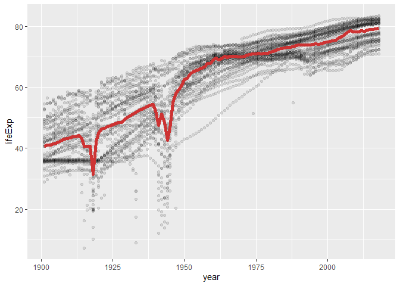

```r
# transformam datele
gapminder_all %>%
  mutate(year = as.numeric(year),
         continent = four_regions) %>%
  filter(year > 1900,
         continent == "Europe") %>%
  ggplot(aes(x = year, y = lifeExp)) +
  # trasam diagrama de imprastiere
    geom_point(alpha = 0.1) +
  # unim punctele mediane
    geom_line(stat = "summary", fun = "median",
              colour = "brown3", linetype = 1, size = 2)
```

Trebuie avut în vedere că atunci când funcțiile `stat_` transformă datele, în realitate se construiește un alt `data.frame` la care pot să apară *noi* variabile (noi coloane) și prin urmare este posibil să utilizăm aceste noi variabile în trasarea graficului. De exemplu, în cazul transformării `stat_bin` (statistica folosită pentru trasarea unei histograme) sunt construite următoarele variabile: `count` - numărul de observații din fiecare subinterval (*bin*), `density` - densitatea observațiilor din fiecare subinterval (procentul din total pe lungimea subintervalului), `x` - centrul subintervalului. Aceste variabile pot fi folosite în trasarea graficului folosind `..` în jurul numelui acestora (i.e. `..[nume variabilă]..`) pentru a evita o eventuală confuzie cu o variabilă din setul de date inițial care are aceeași denumire. Spre exemplu atunci când trasăm o histogramă observăm că în mod automat (implicit) înălțimea barelor este egală cu numărul de observații din subintervalul corespunzător (`count`) prin urmare vorbim de o histogramă de frecvențe și nu una de densitate. Pentru a obține-o pe cea din urmă trebuie să specificăm că înălțimea barelor este dată de variabila `density`. În contextul setului de date `gapminder_2018` aceasta se traduce prin

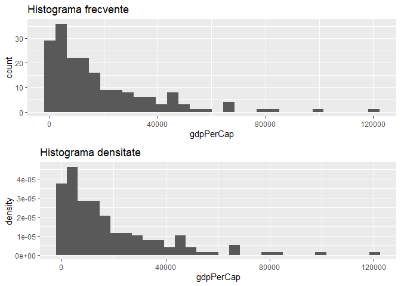

```r
# histograma frecvente
ggplot(gapminder_2018, aes(x = gdpPerCap)) +
  geom_histogram()

# histograma densitate
ggplot(gapminder_2018, aes(x = gdpPerCap)) +
  geom_histogram(aes(y = ..density..))
```

Mai mult dacă dorim să comparăm modul de repartiție a produsului intern brut pe cap de locuitor pentru fiecare continent atunci este recomandată folosirea datelor standardizate:

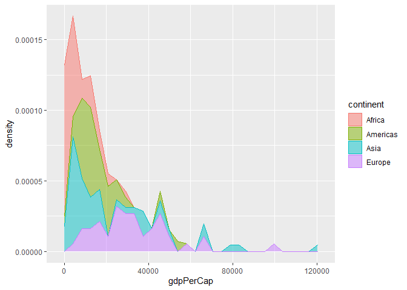

```r
ggplot(gapminder_2018, aes(x = gdpPerCap, colour = continent, fill = continent)) +
  geom_area(stat = "bin", aes(y = ..density..), alpha = 0.5)
```

## 4.6 Gestionarea scalelor (*scales*)

De fiecare dată când specificăm o corespondență de estetică/aspect (*aesthetic mapping*), funcția `ggplot` folosește o anumită *scală* (predefinită în funcție de tipul esteticii) pentru a determina intervalul de valori pe care datele trebuie să le verifice. O corespondență estetică (i.e. specificată cu `aes()`) ne spune doar că o variabilă ar trebui asociată unei caracteristici ce ține de aspect și nu cum trebuie să aibă loc această relație. De exemplu, atunci când folosim estetica `colour` (`aes(colour = x`) nu specificăm nicăieri ce culori trebuie folosite pentru trasarea elementelor specifice nivelelor variabilei `x`. Aceeași observație este valabilă și pentru alte atribute estetice, i.e. `size`, `fill`, `shape`, etc. Pentru a specifica ce culoare, mărime, formă, etc. să fie utilizată trebuie modificată scala corespunzătoare. În pachetul `ggplot2`, scalele (*scales*) pot fi modificate prin intermediul funcțiilor de tipul

```r
scale_[nume estetică]_[tip]
```

unde `nume estetică` reprezintă numele elemntului estetic (i.e. `x`, `y`, `colour`, `fill`, etc.) iar `tip` reprezintă tipul scalei folosite pentru elementul ales (i.e. `continuous`, `discrete`, `manual`, `gradient`, etc.). În funcție de estetică, tipul scalei poate să difere

Trebuie menționat că `ggplot` asociază în mod automat fiecărui element estetic folosit în trasarea graficului o scală. De exemplu dacă scriem

```r
ggplot(gapminder_2018, aes(x = gdpPerCap, y = lifeExp)) +
  geom_point(aes(colour = continent))
```

în realitate are loc

```r
ggplot(gapminder_2018, aes(x = gdpPerCap, y = lifeExp)) +
  geom_point(aes(colour = continent)) +
  scale_x_continuous() +
  scale_y_continuous() +
  scale_color_discrete()
```

dar pentru a evita scrierea manuală a fiecărei scale, `ggplot2` face lucrurile automat. Este foarte important de menționat că scalele pot modifica unul din cele două elemente de ghidaj (*guides*) ale unui grafic: axele și legendele. În `ggplot2` cele două elemente, chiar dacă vizual sunt diferite, ele sunt tratate în mod similar, legătura fiind evidențiată în tabelul următor:

| Axă | Legendă | Numele parametrului |
| --- | --- | --- |
| Nume (*Label*) | Titlu (*Title*) | `name` |
| Markeri (*Ticks & grid line*) | Intrările legendei (*Key*) | `breaks` |
| Etichete Markeri (*Tick label*) | Etichetele intrărilor legendei (*Key label*) | `labels` |

În general, scalele disponibile în `ggplot2` pot fi împărțite în patru categorii, primele trei fiind cele mai utilizate:

- *scale continue de poziție* folosite pentru a face corespondența dintre datele de tip numeric sau de tip temporal (date/time) și poziția pe x sau y (i.e. `scale_x_continuous`, `scale_y_continuous`)
- *scale de culori* care permit corespondența dintre valorile continue sau discrete ale datelor și culori (i.e. `scale_color_discrete`, `scale_fill_continuous`, `scale_fill_gradient`)
- *scale manuale*, utilizate pentru a defini relația dintre valorile discrete ale datelor și mărimea (*size*), tipul liniei (*linetype*), forma (*shape*) sau culoarea (*colour*) dorită
- *scale identice*, folosite pentru a trasa variabilele fără a le scala (de exemplu atunci când avem deja un vector de culori)

O scală continuă va fi folosită cu precădere atunci când vorbim de date numerice (unde există un set continuu de numere), în timp ce o scală discretă va gestiona elemente precum culorile, forma punctelor sau tipul liniilor (deoarece există o listă mică de culori distincte).

În tabelul de mai jos sunt prezentate o parte dintre scalele cele mai utilizate (pentru mai multe detalii se poate consulta documentația pachetului [ggplot2](https://ggplot2.tidyverse.org/reference/index.html#section-scales))

| Scala | Tipul | Exemple |
| --- | --- | --- |
| `scale_color_` | `identity` | `scale_fill_continuous` |
| `scale_fill_` | `manual` | `scale_color_discrete` |
| `scale_size_` | `continuous` | `scale_size_manual` |
|  | `discrete` | `scale_size_discrete` |
| `scale_shape_` | `discrete` | `scale_shape_discrete` |
| `scale_linetype_` | `identity` | `scale_shape_manual` |
|  | `manual` | `scale_linetype_discrete` |
| `scale_x_` | `continuous` | `scale_x_continuous` |
| `scale_y_` | `discrete` | `scale_y_discrete` |
|  | `reverse` | `scale_x_log` |
|  | `log` | `scale_y_reverse` |
|  | `date` | `scale_x_date` |
|  | `datetime` | `scale_y_datetime` |

### 4.6.1 Scale de poziție

Pentru a ajusta scala axei x pentru o variabilă continuă vom folosi `scale_x_continuous`. Utilizarea funcțiilor de scală permite modificarea mai multor proprietăți ale elementului estetic, de exemplu în cazul scalei pe axa x putem modifica aspecte ale axei precum eticheta/titlul axei (*name*), poziția (*position*) sau distanța dintre markeri (*breaks* sau *minor_breaks*) și numele acestora (*labels*). Pentru alte elemente estetice în afara lui x și y, *axa* va fi de obicei legenda graficului și astfel modificarea scalei unui asemenea element permite modificarea elementelor componente ale legendei (nume, etichete, culori, etc.).

Ca exemplu, vom folosi setul de date `gapminder_2018` și folosind `scale_x_continuous` vom modifica numele axei x, poziția markerilor de separare (*breaks*) principali și secundari (*minor_breaks*):

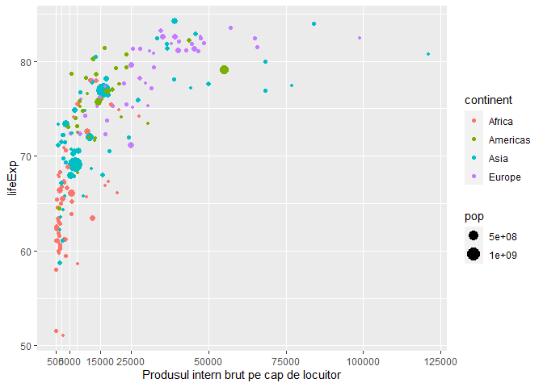

```r
ggplot(gapminder_2018, aes(x = gdpPerCap, y = lifeExp, colour = continent, size = pop)) +
  geom_point() +
  scale_x_continuous(name = "Produsul intern brut pe cap de locuitor",
                     breaks = c(500, 5000, 15000, 25000,
                                50000, 75000, 100000, 125000),
                     minor_breaks = c(500, 2500, 7500))
```

Este posibil să dorim de asemenea schimbarea numelui legendei ce corespunde variabilei `pop` (populației) din *pop* în *Populația*, să afișăm mărimile 1e7, 5e7, 1e8, 2e8, 5e8, 1e9 (*breaks*) și să schimbăm intervalul de valori (minim-maxim) pentru mărimea simbolului (*range*):

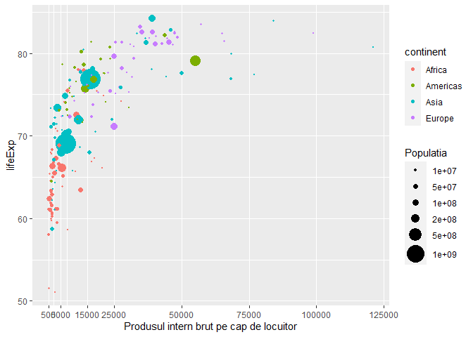

```r
ggplot(gapminder_2018, aes(x = gdpPerCap, y = lifeExp, colour = continent, size = pop)) +
  geom_point() +
  scale_x_continuous(name = "Produsul intern brut pe cap de locuitor",
                     breaks = c(500, 5000, 15000, 25000,
                                50000, 75000, 100000, 125000),
                     minor_breaks = c(500, 2500, 7500)) +
  scale_size(name = "Populatia",
             breaks = c(1e7, 5e7, 1e8, 2e8, 5e8, 1e9),
             range = c(0.1, 10))
```

În plus, putem să adăugăm funcții ca argument al parametrilor `breaks` și `labels`, în primul caz funcția returnând un vector de valori numerice care să corespundă elementelor de marcaj iar în cazul etichetelor va primi ca date de intrare un vector numeric de elemente de marcaj și va returna un vector de etichete. De exemplu, pentru a adăuga simbolul `$` în dreptul valorilor produsului intern brut vom folosi funcții din pachetul `scales` precum `dollar_format()` iar pentru a modifica axa y vom crea propria funcție:

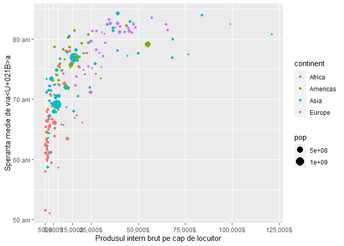

```r
ggplot(gapminder_2018, aes(x = gdpPerCap, y = lifeExp, colour = continent, size = pop)) +
  geom_point() +
  scale_x_continuous(name = "Produsul intern brut pe cap de locuitor",
                     breaks = c(500, 5000, 15000, 25000,
                                50000, 75000, 100000, 125000),
                     minor_breaks = c(500, 2500, 7500),
                     labels = scales::dollar_format(prefix = "", suffix = "$")) +
  scale_y_continuous(name = "Speranta medie de viață",
                     labels = function(x){paste(x, "ani")})
```

Fiecare funcție de scalare permite utilizarea unui număr diferit de parametrii, o parte dintre aceștia regăsindu-se în tabelul de mai jos (pentru a vizualiza toți parametrii disponibili se poate consulta documentația funcției, i.e. `?scale_x_continous`):

| Parametru | Descriere |
| --- | --- |
| `name` | Eticheta (label) axei sau numele legendei |
| `breaks` | Vector de puncte de marcaj |
| `minor_breaks` | Vector de puncte de marcaj intermediare |
| `labels` | Etichete folosite pentru fiecare punct de marcaj |
| `limits` | Limitele intervalului de valori ale axei |

Modul de folosire a parametrilor `name`, `breaks`, `minor.breaks` și `labels` a fost ilustrat în exemplele anterioare. Parametrul `limits` este derivat din domeniul de valori al setului de date și este folosit cu precădere pentru a scoate în evidență o subregiune a graficului. Atunci când facem referire la scale continue parametrul `limits` primește ca argument de intrare un vector cu două valori (minim și maxim).

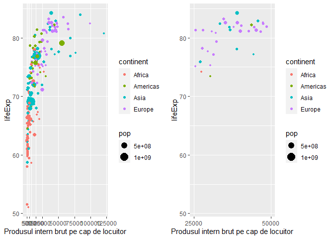

```r
ggplot(gapminder_2018, aes(x = gdpPerCap, y = lifeExp, colour = continent, size = pop)) +
  geom_point() +
  scale_x_continuous(name = "Produsul intern brut pe cap de locuitor",
                     breaks = c(500, 5000, 15000, 25000,
                                50000, 75000, 100000, 125000),
                     minor_breaks = c(500, 2500, 7500),
                     limits = c(25000, 50000))
```

Deoarece modificarea limitelor axelor este o operație des întânlnită atunci când efectuăm analize exploratorii a datelor cu care lucrăm, pachetul `ggplot2` pune la dispoziție o serie de funcții predefinite precum `xlim()`, `ylim()` sau `lims()`.

Pachetul `ggplot2` pune la dispoziție și o serie de scale care permit modificarea axelor, de exemplu, prin inversarea valorilor (i.e. `scale_x_reverse`) sau prin transformarea acestora într-o scală logaritmică (folosind `scale_x_log10` sau `scale_x_continuous(trans = "log10")`) ori printr-o altă funcție (i.e. `scale_x_sqrt` sau `scale_x_continuous(trans = "sqrt")`). Pentru mai multe transformări se poate consulta documentația funcției `scale_x_continuous` la argumentul `trans`.

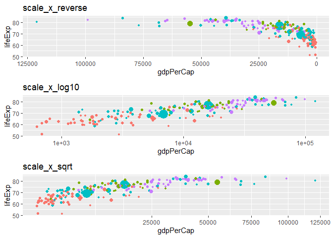

Atunci când avem de-a face cu variabile/date care sunt în format de date de timp (format `Date` sau `POSIXct`) este recomandată utilizarea funcțiilor predefinite `scale_x_date` și respectiv `scale_x_datetime` care dispun în plus de argumentele `date_breaks` și `date_labels`. Argumentul `date_breaks` permite poziționarea elementelor de marcaj în funcție de unitățile de timp (ani, luni, săptpmâni, etc.), astfel `date_breaks = 2 years` va pasa marcaje din doi în doi ani. Argumentul `date_labels` asigură ilustrarea etichetelor pentru marcaje în format `strptime()`.

| Sir de caractere | Descriere |
| --- | --- |
| `%S` | secunde (00-59) |
| `%M` | minute (00-59) |
| `%l` | ore, format ceas 12 ore (1-12) |
| `%I` | ore, format ceas 12 ore (01-12) |
| `%p` | am/pm |
| `%H` | ore, format ceas 24 ore (00-23) |
| `%a` | zilele săptămânii, sub forma (Mon-Sun) |
| `%A` | zilele săptămânii, sub forma (Monday-Sunday) |
| `%e` | ziua din lună (1-31) |
| `%d` | ziua din lună (01-31) |
| `%m` | luna, format numeric (01-12) |
| `%b` | luna, format abreviat (Jan-Dec) |
| `%B` | luna, nume întreg (January-December) |
| `%y` | an, fără specificarea secolului (00-99) |
| `%Y` | an, cu specificarea secolului (0000-9999) |

De exemplu dacă vrem să afișăm date precum 23/08/1944 vom folosi șirul de caractere `"%d/%m/%Y"`. Următorul cod ilustrează aceste opțiuni în contextul setului de date `gapminder_all` unde ne interesăm la evoluția duratei medii de viață în țara noastră după anul 1900.

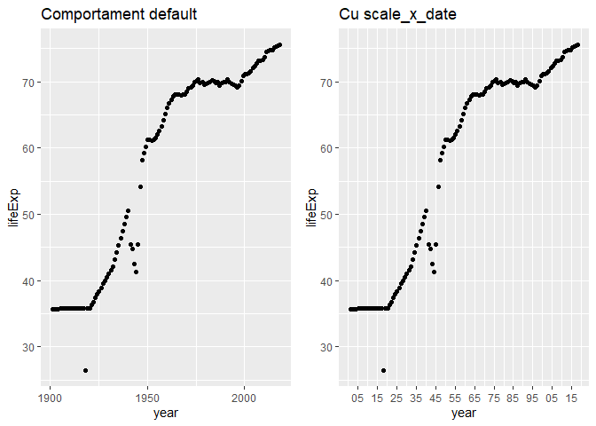

```r
gapminder_all %>%
  filter(country == "Romania",
         as.numeric(year) > 1900) %>%
  mutate(year = as.Date(year, format = "%Y")) %>%
ggplot(aes(x = year, y = lifeExp)) +
  geom_point() +
  scale_x_date(date_labels = "%y", date_breaks = "10 years")
```